# Your Digest for Monday, Aug 07, 2023 11:59 PM

# Renal acid base handling

## Physiology

### Relationship between H+ extretion and HCO3 reabsorption

$$
\ce{H2O + CO2 <=> H2CO3 <=> H+ + HCO3- }
$$
The body is constant producing acid by way of formation of

1. volatile acids - I.e **CO2** which leads to production of H+.
2. non volatile acids - i.e lactate, phosphate, sulphate etc.

Amount of acid produced by CO2 far exceeds the acid load due to non-volatile acids.

pH homeostasis is maintained by 3 systems:

1. Immediate - blood HCO3 buffer. (which has a HUGE but finite capacity).
   1. pKA of H2CO3 is 6.1; A buffer solution is most effective at maintaining a pH near it's pKA. But the HCO3 buffer is sufficient to maintain body pH at 7.35-7.45 because it's 'open' at both ends (due to the effects of the repiratory system and renal system)
2. Lungs - short term
3. Kidneys - medium to long term but most powerful system.

Here, we talk about the kidneys' role only.

To maintain pH, the kidney has to

1. excrete this acid load
2. prevent loss of bicarbonate.
   - A massive amount of bicarbonate is filtered by the kidneys. (24 mEq / L x 180 L / day).
   - Only 2mEq of HCO3 are lost in the urine. Therefore, the vast majority of HCO3 is reabsorbed. If HCO3 is continuosly lost, the equation above shifts to the right and H+ increases and pH drops. => **acidosis.**

**H+ elimination by the kidney** requires that the secreted H+ be buffered in the urine; or else the pH would drop and prevent continued excretion of sufficient H+.  
There are 3 buffers.

1. The first buffer eliminates H+ but also helps to reabsorb most of the filtered bicarbonate --> Win Win situation!
2. The second and third buffers create "**new**" bicarbonate.

The HOC3- buffer in urine serves the dual role of

1. Allowing reabsorption of bicarbonate
2. allowing secretion of H+

The other two buffers are used when excess acid must be secreted.  
They have important, unique features.

| HCO3 | HPO42-- | NH3 |
| --- | --- | --- |
| Obligatory for life | Cannot be regulated | Upregulated in response to acid |

## Compensation for metabolic acidosis

### Identifying the cause of metabolic acidosis

In metabolic acidosis due to *GI* loss of HCO3, the kidney responds by increasing ammonium -> i.e causing a net loss of H+ from the body. => **decreased urinary anion gap**.

In metabolic acidosis due to loss of base by the kidney - primary problem is most probably renal. The kidney can't increase ammonium excretion => **urine anion gap NOT increased.**

[video not shown]

# ADPKD - polycystic kidney disease

Autosomal dominant. Patients present in family groups.😊😔  
It's a common disease (1/1000) incidence.  
Commonest mutation is in chromosome 16.

Risk factors for progressive renal disease:

- Male gender
- kidney size
- earlier onset of symptoms
- proteinuria
- High urinary sodium excretion
- hypertension - patients with larger kidneys tend to have hypertension.
- haematuria was *not* mentioned

🟢PKD2🟢 is less severe than 🔴⚠️PKD1⚠️🔴  
PKD 1:

- Earlier presentation with symptoms
- More cysts
- Larger kidneys
- Earlier onset of CK

## Clinical detection

> The diagnosis is most commonly made in the settings of
> - **routine evaluation in an asymptomatic patient** with a positive family history of ADPKD,
> - initial work-up for *new-onset hypertension*,
> - as an **incidental finding** during an imaging study performed for an unrelated reason (eg, pregnancy, trauma, spinal pain),
> - and during evaluation of **ADPKD-specific** symptoms (hematuria, cyst rupture, pyelonephritis, kidney stones, etc).

#### Presenting complaints:

- **commonest** - flank pain due to come colocation of PKD
- hypertension
  - Hypertension is very common by 30-40 years. (Even when renal function is normal)
- hematuria,
- proteinuria,
- kidney function impairment.

Diagnosis is **primarily** by **imaging**. (Genetic testing usually not required).  
All patients will develop renal cysts.

Imaging Criteria overview:  
For patients who *have a family history*  
For young adults, > total of 3 cysts  
For older adults(40 y/o and above), > 2 cysts in *each* kidney.  
For patients without a family history, there are no well defined imaging diagnostic criteria.  
Cut-off of 10 or more cysts *per kidney* is reasonable.

## Extra renal manifestations

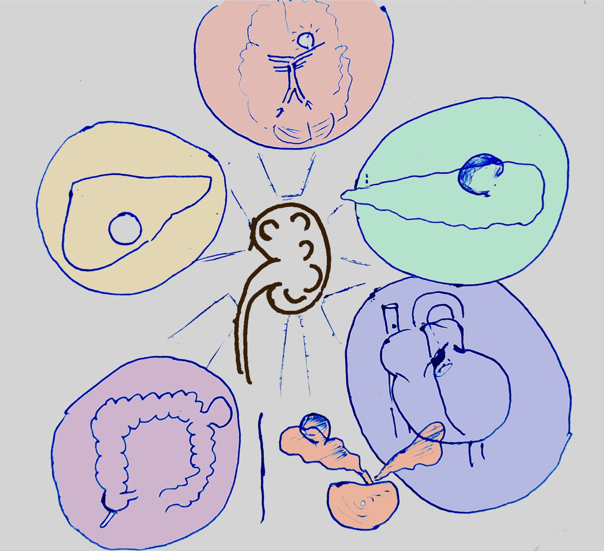

- Cerebral vasculature aneurysms
  - rupture causing SAH is the most dangerous complication of PKD.
  - one in 10 patients with PKD have intracranial aneurysms.
  - doubly dangerous becuase these patients also have *hypertension!*
  - screening for aneurysm is not done routinely. (Recommended in some situations such as when patient has a high risk job); CT angiography is used for screen I
- Hepatic and pancreatic cysts
  - hepatic cysts usually only cause pain when the become large enough.
- Valvular dysfunction - MR and AR + coronary aneurysms
- Colonic diverticulae
- Seminal vesicle cysts

# Antiepileptic medications

## Mechanisms of action

For some drugs, precise mechanism is unknown or several mechanisms are suspected.

See table in up to date

> Alteration of sodium currents is the most common mechanism of action of available antiseizure medications.

Type of receptor blockade may explain why some drugs are more effective for particular types of seizures.

*Phenytoin , phenobarbitone and carbamazepine are some of the oldest antiseizure medications.* - Newer drugs have better pharmacokinetics.

### Carbamazepine

Binds Na Channels

> This binding extends the inactivated phase and inhibits the generation of rapid action potentials when the cell is experiencing incoming depolarizing trains

### Phenytoin and fosphenytoin

#2023SBR Q23

Fosphenytoin is the prodrug. Superceded Phenytoin for IV use. (? Not really in SL)  
Block Na channels, like carbamazepine.  
Inhibits synaptic transmission.  
And others...

#### seizure types

focal and generalized seizures  
for status epilepticus  
and as a second-line agent for patients with mixed seizures

#### Pharmacology of Phenytoin

95% protein bound ; renal failure impairs protein binding.  
Valproate is another highly protein bound drug which ?may displace Phenytoin and increase its plasma levels.

**potent, broad spectrum** CYP and glucuronidation inducer.

**Side effects:**  
*Systemic*: gingival hypertrophy, body hair increase, rash, folic acid depletion, reduced bone density (enzyme induction -> incr. Vitamin D catabolism)

Stevens-Johnson / TEN (**commoner in south Asia!**)

*Neurologic* :  
confusion  
Slurred speech, ataxia, diplopia (all involving the head region)  
Neuropathy

### Phenobarbital

Binds GABA-A receptor, potentiates GAABA action, causing hyper polarization and increased neuronal stability.

**potent, broad spectrum** CYP and glucuronidation inducer.

Side effects:  
**Commonest side effect:** sedation, reduced concentration, and mood changes including depression

**Teratogenicity** with #pregnancy is another risk, with a relatively high rate of major malformations in fetuses exposed to phenobarbital.

Chronic use is associate with an increased risk of decreased bone density, Dupuytren contractures, plantar fibromatosis, and frozen shoulder.